# Lab Assignment 5

Samantha Chen

4/30/2021

## Question 1: Dandelions and the Habitat Edge

```r
# modifying data
plantdata <- read.csv("~/EEMB 146 Lab Files/Lab 5 Data/plant_data.csv")
sub_plant_data <- plantdata[plantdata$dist_from_edge_m != "3.0m",]
levels(sub_plant_data$dist_from_edge_m)
```

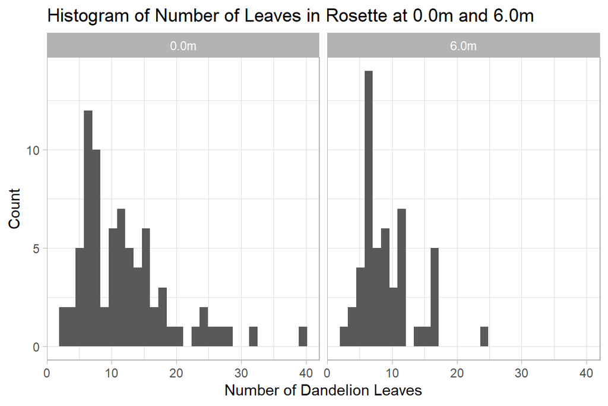

```r
# visualizing data --histogram
ggplot(sub_plant_data, aes(x = num_leaves_in_rosette)) +  #histogram
  geom_histogram() +
  facet_wrap(~ dist_from_edge_m) +  #separates histogram based on a certain grouping
  theme_light() +
  stat_bin(bins = 30) +
  labs(x = "Number of Dandelion Leaves", y = "Count") +
  ggtitle("Histogram of Number of Leaves in Rosette at 0.0m and 6.0m")
```

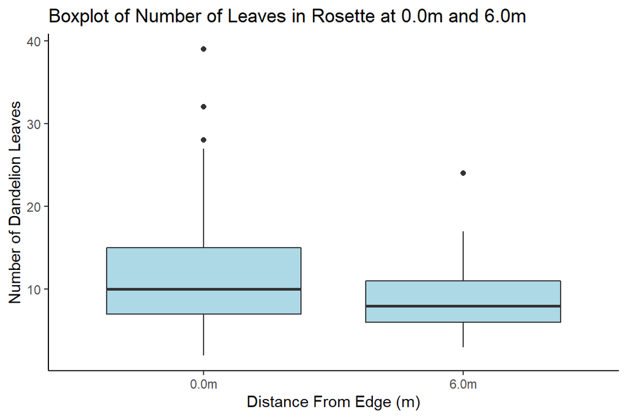

```r
#boxplot
ggplot(sub_plant_data, aes(x = dist_from_edge_m, y = num_leaves_in_rosette)) +
  geom_boxplot(fill = "lightblue") +
  theme_classic() +
  labs(x = "Distance From Edge (m)", y = "Number of Dandelion Leaves") +
  ggtitle("Boxplot of Number of Leaves in Rosette at 0.0m and 6.0m")
```

# Observations

The histogram of both 0.0m and 6.0m show asymmetry suggesting the data is not normal. Histogram of 0.0m has a tail indicating a right skew while histogram of 6.0m doesn’t have a tail but still looks like it is right skewed as well. Based on the boxplots 0.0m data show has 3 outliers while 6.0m has 1. It makes sense that 0.0m has more outliers because it is right skewed.In addition, 0.0m show a larger spread than 6.0m.

```r
# checking normality of data through residuals
fit_plant <- lm(num_leaves_in_rosette~dist_from_edge_m, data = sub_plant_data)
res_plant = fit_plant$residuals

shapiro.test(res_plant) # p-value = 3.647e-08
```

```
##
##  Shapiro-Wilk normality test
##
## data:  res_plant
## W = 0.89044, p-value = 3.647e-08
```

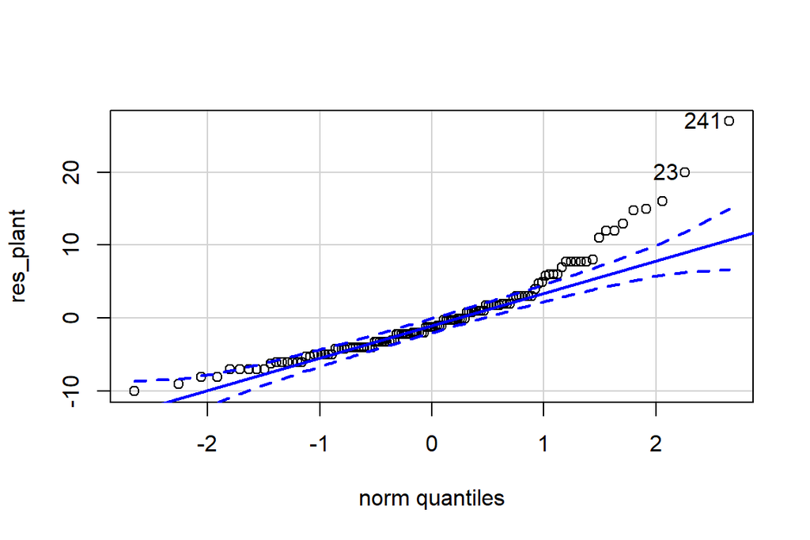

```
## 241  23
## 121   3
```

```r
qqPlot(res_plant)
```

# 1A Part 1

A Shapiro-Wilk test was done on the residuals of dist_from edge_m vs. num_leaves_in_rosette. The null hypothesis (H_0) is that the residual data is normal and the alternative hypothesis (H_A) is that the residual data is not normal. Because the residual data got a p-value of 3.647e-08, which is much smaller than p = 0.05. I reject the hypothesis and can confidently say that the residual data is not normal. In addition, the qqPlot shows areas where many datapoints were not within the confidence bands which is also an indication of non-normal data. We could assume that the data is normal based on the Central Limit Theorem because the sample size is N > 50. However I’m going to log transform the data to double check normality.

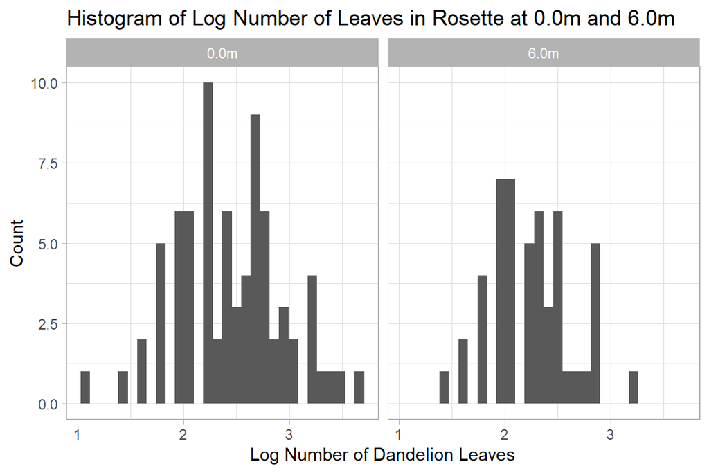

```r
# log transform data
sub_plant_data$log_num_leaves_in_rosette <- log(sub_plant_data$num_leaves_in_rosette + 1)

ggplot(sub_plant_data, aes(x = log_num_leaves_in_rosette)) +
  geom_histogram() +
  facet_wrap(~ dist_from_edge_m) +
  theme_light() +
  stat_bin(bins = 30) +
  labs(x = "Log Number of Dandelion Leaves", y = "Count") +
  ggtitle("Histogram of Log Number of Leaves in Rosette at 0.0m and 6.0m") #Both histograms look normal
```

```r
# residuals of log plant data
fit_log_plant <- lm(log_num_leaves_in_rosette~dist_from_edge_m, data = sub_plant_data)
res_log_plant = fit_log_plant$residuals

shapiro.test(res_log_plant) # p-value = 0.798
```

```
##
##  Shapiro-Wilk normality test
##
## data:  res_log_plant
## W = 0.99312, p-value = 0.798
```

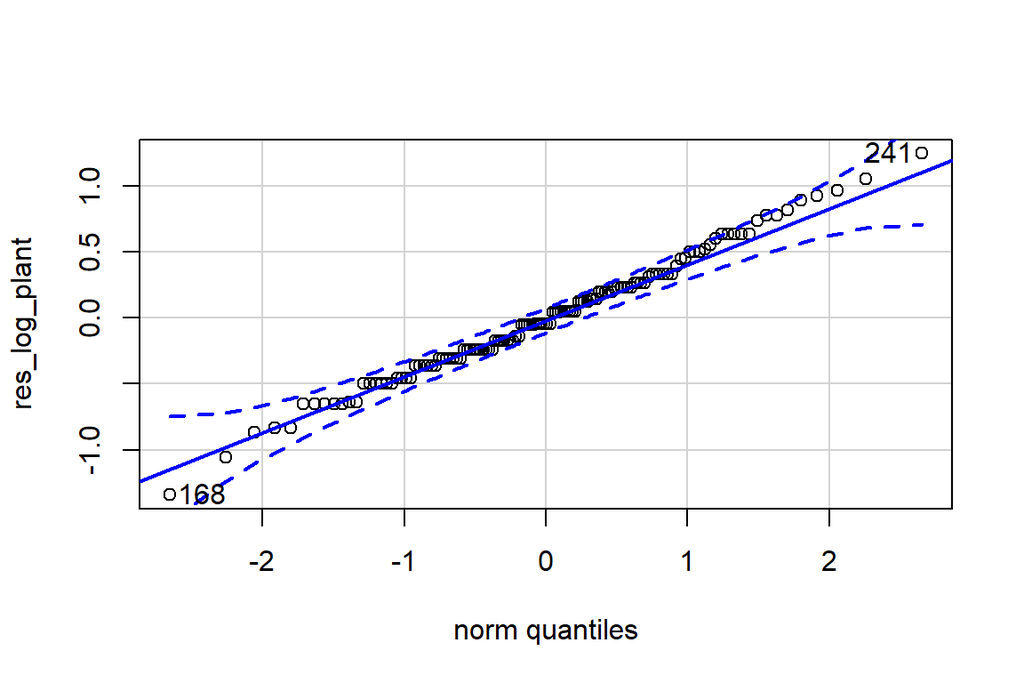

```
## 168 241
##  79 121
```

```r
qqPlot(res_log_plant)
```